# 01_ Mixture 2 Gaussian_1 Dimention

Tran Le

2/24/2022

# 1 Introduction

Here is the R code that I use to illustrate a simulation example using the EM algorithm for Gaussian mixture models with 2 (Gaussian) distributions in 1D. The EM formula construction and the pseudo-code can be found [here](https://tranktle.github.io/portfolio/2022/03/31/EM-Mixture-Gaussian.html). Also, some note EM algorithm for a Mixture of $k>=2$ Gaussian distributions in 1D and 2D could be found [here](https://tranktle.github.io/portfolio/2022/03/31/EM-Mixture-Gaussian.html).

This is the Pseudo-code for estimating parameters that we can use for simulation.

1. Set initial values: $\mu_1^{(0)}, \sigma_1^{2(0)}, \mu_2^{(0)}, \sigma_2^{2(0)}, p^{(0)}$
2. For each EM iteration step
1. Update posterior probability

$$\begin{equation}
\pi_i^{(s)} := \frac{p^{(s)}f_1^{(s)}(y_i)}{p^{(s)}f_1^{(s)}(y_i) + (1-p^{(s)}) f_2^{(s)}(y_i)}
\end{equation}$$

2. Update parameter estimations $p^{(s+1)}$, $\mu_1^{(s+1)}, \sigma_1^{(s+1)}, \mu_2^{(s+1)}, \sigma_2^{(s+1)}$.

$$\begin{align*}
\hat{p}^{(s+1)}&=\frac{\sum_{i=1}^n \pi_i^{(s)}}{n}\\
\hat{\mu}_1^{(s+1)} &= \frac{\sum_{i=1}^n \left[\pi_i^{(s)}y_i\right]}{\sum_{i=1}^n \pi_i^{(s)}}\\
\hat{\sigma}_1^{2(s+1)} &= \frac{\sum(y_i-\hat{\mu}_i^{(s+1)})^2\pi_i^{(s)}}{\sum_{i=1}^n \pi_i^{(s)}}
\hat{\mu}_2^{(s+1)} &= \frac{\sum_{i=1}^n \left[(1-\pi_i^{(s)})y_i\right]}{\sum_{i=1}^n(1- \pi_i^{(s)})}\\
\hat{\sigma}_2^{2(s+1)} &= \frac{\sum(y_i-\hat{\mu}_2^{(s+1)})^2(1-\pi_i^{(s)})}{\sum_{i=1}^n (1-\pi_i^{(s)})}
\end{align*}$$

3. Stopping criteria for step (2.): Define $\boldsymbol{\theta} := (p, \mu_1, \sigma_1^2, \mu_2, \sigma_2^2)$
1. $\boldsymbol{\theta}$ stop changing: $\Vert \boldsymbol{\theta}^{(s+1)}-\boldsymbol{\theta}^{(s)}\Vert < \epsilon_1$.
2. or when log-likelihood stop changing: $|l(\boldsymbol{\theta^{(s+1)}})-l(\boldsymbol{\theta^{(s)}})|<\epsilon_2$

# 2 Utility functions

First, we will have some utility functions that will be used in the main EM function.

```r
library(ggplot2)
library(tidyverse)
library(hrbrthemes)
library(cowplot) #to use plot_grid
library(janitor)
```

- A function to create a simulation data set of a two-components Gaussian mixture distribution with sample size $n$ with component distribution: $Y_1\sim N(\mu_1, \sigma_1)$ account for $p1=p\%$ of the data and $Y_2 \sim N(\mu_2, \sigma_2)$ account for $p2=(1-p)\%$ of the data

```r
creat_dat_f <- function(n, p, mu1, sig1, mu2, sig2){
   # # Create synthesis data
   # n: the total sample size of the two distribution
   # p: the probability of a data point belongs to the 1st distribution
   n1 <- floor(n*p)
   Y1 <- rnorm(n1, mu1, sig1)
   n2 <- ceiling(n*(1-p))
   Y2 <- rnorm(n2, mu2, sig2)
   data <- data.frame(
      distri = c( rep("1", n1), rep("2", n2) ),
      value = c( Y1,Y2)
   )
   return(data)
}
```

- A function to plot the above simulated data

```r
plot_syn_dat_f <- function(data){
   # a data set created by function creat_dat_f
   p1 <- data %>%
      ggplot(aes(x=value, fill=distri), addDensityCurve=TRUE) +
      geom_histogram( color="#e9ecef", alpha=0.6, position = 'identity', binwidth=1) +
      scale_fill_manual(values=c("#69b3a2", "#404080"))
   # +  theme_ipsum() + labs(fill="Dist")
   p2 <- data %>%
      ggplot(aes(x=value)) +
      geom_histogram( color="#e9ecef", alpha=0.6, position = 'identity', binwidth =1)
   # + theme_ipsum()
   theplot <- plot_grid(p1, p2, labels=c("Original data","Mixture data"), ncol = 2, nrow = 1)
   return(theplot)
}
```

```r
com_pi_f <-function(p, y, mu1, sig1, mu2, sig2){
   # compute posterior probability associative with each yi
   pi_mumer <- (p*dnorm(y, mean = mu1, sd = sig1))
   pi <- pi_mumer / (pi_mumer+(1-p)*dnorm(y, mean = mu2, sd = sig2))
   return(pi)
}
com_Ui_f <- function(dist_thres_prob, pi){ifelse(pi>dist_thres_prob, 1, 2)}
#
com_U_vec_f <- function(dist_thres_prob, p, Y, mu1, sig1, mu2, sig2){
   pi_vec <- map_dbl(Y, ~com_pi_f(p, .x,  mu1, sig1, mu2, sig2))
   Ui_vec <- map_dbl(pi_vec, ~com_Ui_f(dist_thres_prob, .x))
   return(Ui_vec)
   }
```

- A function to compute complete-data log-likelihood function, this will be used for stopping criterion.

```r
#
# This will be used to consider EM stopping criteria
log_like_comp_f <- function(dist_thres_prob, p, Y, mu1, sig1, mu2, sig2){
   # Function to compute log-likelihood based on updated data
   # 0< dist_thres_prob < 1: distribution threshold probability, to decide which
   # distribution (dist 1 or dist 2)that the data point belong to
   # Y: vector contains the observed data
   # p: updated P(Y is in distribution 1)
   # mu1, sig1, mu2, sig2: parameters of the two Gaussian distributions
   # ll: log-likelihood of complete data
   pi_vec <- map_dbl(Y, ~com_pi_f(p, .x,  mu1, sig1, mu2, sig2))
   Ui_vec <- map_dbl(pi, ~com_Ui_f(dist_thres_prob, .x))
   ll <- sum(Ui_vec*log(p*dnorm(Y, mu1, sig1)) + (1-Ui_vec)*log((1-p)*dnorm(Y, mu2, sig2)))
   return(ll)
}
```

- The EM-main function.

```r
EM_two_gaussian_f <- function(mu1_0, sig1_0, mu2_0, sig2_0, p_0, Y, max_iter, eps, dist_thres_prob, verbose) {
   # Function to estimate parameters based on initial guesses
   # mu1_0, sig1_0, mu2_0, sig2_0, p_0: initial parameter values
   # Y: observed data (a vector)
   # max_iter: maximum number of EM iteration
   # eps: threshold for stopping criteria
   # dist_thres_prob: distribution threshold probability, to decide which
   #                  distribution (dist 1 or dist 2)that the data point belong to
   # verbose = T if you want to see the updated estimation values in each iteration step
   mu1 <- mu1_0; sig1 <- sig1_0; mu2 <- mu2_0; sig2 <- sig2_0; p <- p_0
   n <- length(Y)
   for (i in (1:max_iter)){
      # Compute the (s+1) step from (s) step
      pi <- map_dbl(Y, ~com_pi_f(p, .x,  mu1, sig1, mu2, sig2))
      mu1_new <- sum(pi*Y)/sum(pi)
      sig1_new <- sqrt(sum(((Y-mu1)^2)*pi)/sum(pi))
      mu2_new <- sum((1-pi)*Y)/(sum(1-pi))
      sig2_new <- sqrt(sum(((Y-mu2)^2)*(1-pi))/(sum(1-pi)))
      p_new <- sum(pi)/n
      # Check stopping criteria
      ll <- log_like_comp_f(dist_thres_prob, p, Y, mu1, sig1, mu2, sig2)
      ll_new <- log_like_comp_f(dist_thres_prob, p_new, Y, mu1_new, sig1_new, mu2_new, sig2_new)
      if (abs(ll_new-ll)<eps) {break}
      # Update
      p <- p_new
      mu1 <- mu1_new; sig1 <- sig1_new
      mu2 <- mu2_new; sig2 <- sig2_new
      if(verbose){cat("\n at step ", i, ": ", p, mu1, sig1, mu2, sig2)}
   } # end for loop

   # If we don't stop before the max_iteration, it means the stopping criterion is not meet
   if (i==max_iter){cat("\n The stopping criterium does not meet \n")}
   return(list(i=i, p= p_new, mu1 = mu1_new, sig1=sig1_new, mu2=mu2_new, sig2 = sig2_new))
}
```

- After we run the EM algorithm, we have the estimated values for the parameters. We could do further by trying to do the clustering and plot the predicted clustering label result compared with the true simulated data label.

```r
create_comp_dat <- function(data, EX, dist_thres_prob){
   # Create comparative data that contain true and EM predicted cluster
   U_vec <- com_U_vec_f(dist_thres_prob, EX1$p, Y=data$value,
                        mu1=EX1$mu1, sig1=EX1$sig1, mu2=EX1$mu2, sig2=EX1$sig2)
   compare_dat <- cbind(data, U_vec) %>% mutate(distri = as.numeric(distri)) %>%
      mutate(err= distri-U_vec)
   return(compare_dat)
}
```

```r
plot_org_pre_dat_f <- function(comp_dat){
   # Plot the original and predicted data gotten from EM algorithm
   comp_dat <- comp_dat %>% mutate(distri = as_factor(distri),
                                   U_vec = as_factor(U_vec))
   p1 <- comp_dat %>%
      ggplot(aes(x=value, fill=distri), addDensityCurve=TRUE) +
      geom_histogram( color="#e9ecef", alpha=0.6, position = 'identity', binwidth=1) +
      scale_fill_manual(values=c("#69b3a2", "#404080"))

   # +  theme_ipsum() + labs(fill="Dist")
   p2 <- comp_dat %>%
      ggplot(aes(x=value, fill=U_vec), addDensityCurve=TRUE) +
      geom_histogram( color="#e9ecef", alpha=0.6, position = 'identity', binwidth=1) +
      scale_fill_manual(values=c("#69b3a2", "#404080"))
   # + theme_ipsum()
   theplot <- plot_grid(p1, p2, labels=c("Original data","Predicted data"), ncol = 2, nrow = 1)
   return(theplot)
}
```

# 3 Example 1

In this example we use a data set generated from a two-components Gaussian mixture distribution with sample size $n=700$ and the true parameters $p_1=p_2=0.5; Y_1\sim N(50, 3); Y_2 \sim N(75, 7)$

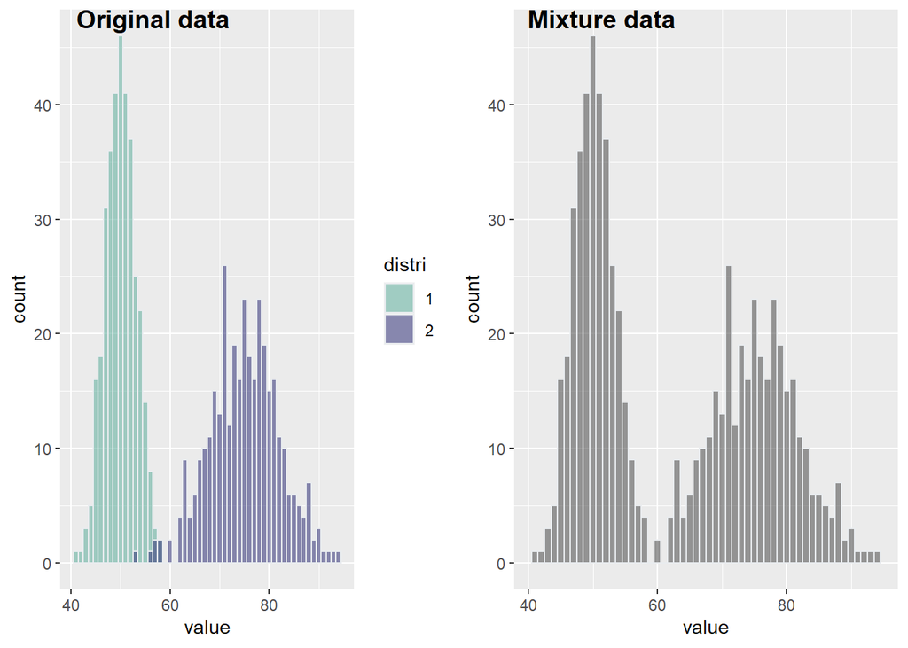

```r
# set up the true parameters-
set.seed(538725)
data <- creat_dat_f(n=700, p=0.5, mu1=50, sig1=3, mu2=75, sig2=7)
# png("./EX_Result/EX1_data.png");
plot_syn_dat_f(data)
```

```r
# dev.off()
```

- Compute the mean and standard deviation of the synthesis data, it makes sense that we can use the standard deviations for each of the components equal to the standard deviation of the mixture data divided by 2.

```r
EX1_mean <- mean(data$value)
EX1_sd <- sd(data$value)
```

- Solve the problem using Em

```r
# Set up initial values
EX1_ini <- data.frame( p=0.5, mu1=40, sig1=EX1_sd/2, mu2=50, sig2=EX1_sd/2,
                       max_iter=50, eps= 0.1, dis_thres_prob = 0.5)
EX1 <- EM_two_gaussian_f(mu1_0 = EX1_ini$mu1, sig1_0= EX1_ini$sig1,
                         mu2_0=EX1_ini$mu2, sig2_0=EX1_ini$sig1,
                         p_0=EX1_ini$p, Y= data$value, max_iter=EX1_ini$max_iter,
                         eps=EX1_ini$eps, dist_thres_prob=EX1_ini$dis_thres_prob, verbose=F)
EX1<- as.data.frame(EX1)
cat("\n EX1 initial values: "); print(EX1_ini)
cat("\n EX1 parameter estimation  result: "); print(EX1)
```

```
   EX1 initial values:     p mu1     sig1 mu2     sig2 max_iter eps dis_thres_prob
  1 0.5  40 6.806516  50 6.806516       50 0.1            0.5

   EX1 parameter estimation  result:    i         p      mu1     sig1      mu2    sig2
  1 21 0.5040023 50.05578 3.123599 75.08268 6.89145
```

From the above table, we see that the EM algorithm converges after 21 iterations. The first Gaussian distribution is estimated to comprise $50.4\%$ of the data with $\hat{\mu_1}=$ 50.0557754 and $=$3.1235994. The second Gaussian distribution is estimated to comprise $1-\hat{p_1}$ of the data with $\hat{\mu_2}=$ 75.0826812 and $\hat{\sigma_2}=$ 6.8914501

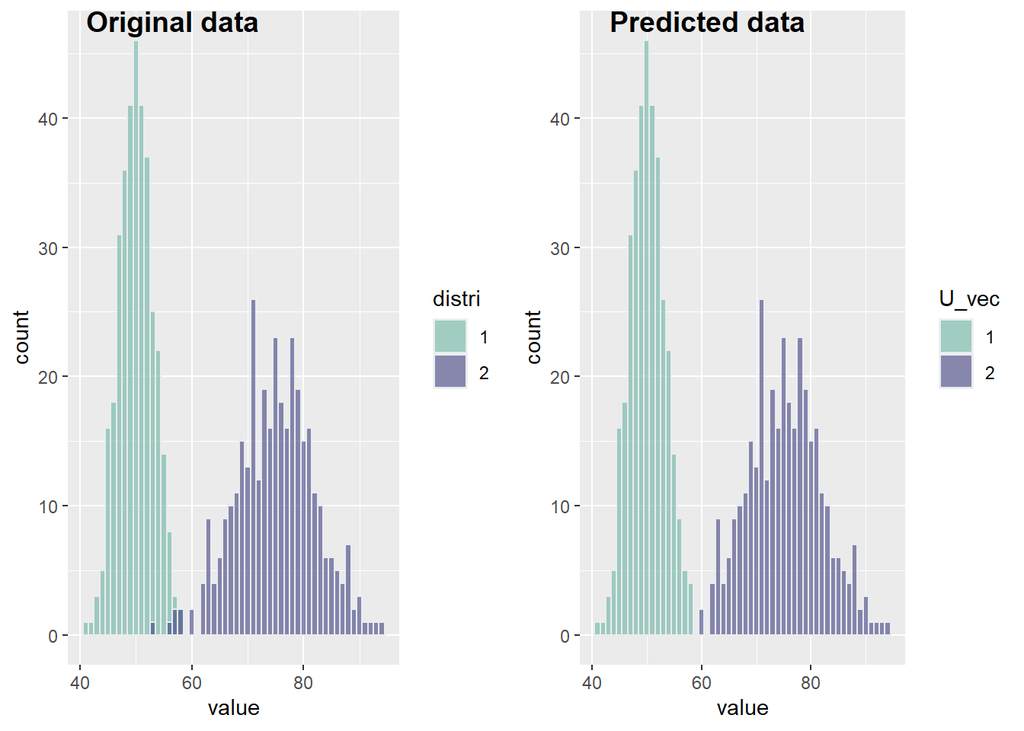

```
  png
    2

   EX1 clustering results:
    err   n
  1   0 694
  2   1   6
```

```r
EX1_comp_dat <- create_comp_dat(data, EX1, dist_thres_prob=EX1$p)
EX1_err <- EX1_comp_dat %>% count(err)
png("./EX_Result/EX1.png");plot_org_pre_dat_f(EX1_comp_dat);dev.off()
# save(EX1_ini, EX1, EX1_err, file= "./EX_Result/EX1.RData")
cat("\n EX1 clustering results: \n"); print(EX1_err)
plot_org_pre_dat_f(EX1_comp_dat)
```

# 4 Example 2: Two Gaussian distributions in 1 D (with inseparable clusters)

This example is similar to Example 1. However, when there are too many overlapped points, we see that the parameter estimation still performs well but the clustering result is not that good.

```r
set.seed(538725)
data <- creat_dat_f(n=700, p=0.5, mu1=50, sig1=16, mu2=75, sig2=9)
png("./EX_Result/EX2_data.png");plot_syn_dat_f(data);dev.off()
EX2_sd <- sd(data$value)
EX2_ini <- data.frame( p=0.5, mu1=25, sig1=5, mu2=75, sig2=12,
                       max_iter=500, eps= 0.01, dis_thres_prob = 0.5)
```

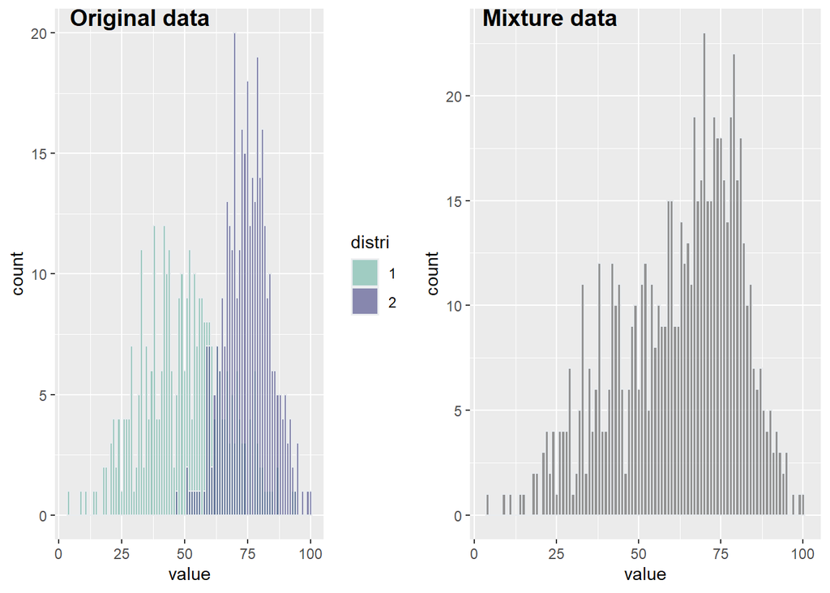

```r
EX2 <- EM_two_gaussian_f(mu1_0 = EX2_ini$mu1, sig1_0= EX2_ini$sig1,
                          mu2_0=EX2_ini$mu2, sig2_0=EX2_ini$sig2,
                          p_0=EX2_ini$p, Y= data$value, max_iter=EX2_ini$max_iter,
                          eps=EX2_ini$eps, dist_thres_prob= EX2_ini$dis_thres_prob, verbose=F) %>%
       as.data.frame()
 EX2_comp_dat <- create_comp_dat(data, EX2, dist_thres_prob=EX2$p)
 EX2_err <- EX2_comp_dat %>% tabyl(err)
 png("./EX_Result/EX2.png");plot_org_pre_dat_f(EX2_comp_dat);dev.off()
 save(EX2_ini, EX2, EX2_err, file= "./EX_Result/EX2.RData")
 # Print the result
 plot_syn_dat_f(data)
```

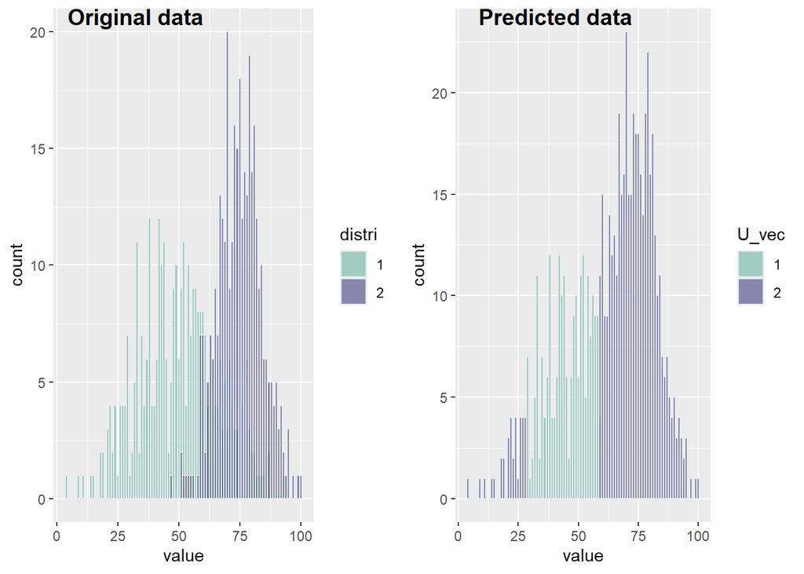

```
  png
    2

   EX2 initial values:
      p mu1 sig1 mu2 sig2 max_iter  eps dis_thres_prob
  1 0.5  25    5  75   12      500 0.01            0.5

   EX2 parameter estimation result:
      i         p      mu1     sig1      mu2    sig2
  1 362 0.4414226 47.18159 14.96152 74.52786 9.16657

   EX2 clustering results:
   err   n    percent
    -1 139 0.19857143
     0 550 0.78571429
     1  11 0.01571429
```

```r
 cat("\n EX2 initial values: \n") ; print(EX2_ini)
 cat("\n EX2 parameter estimation result: \n"); print(EX2)
 cat("\n EX2 clustering results: \n"); print(EX2_err)
 plot_org_pre_dat_f(EX2_comp_dat)
```

# 5 Reference

McLachlan, G. J., & Krishnan, T. (2007). The EM algorithm and extensions (Vol. 382). John Wiley & Sons.

Ng, A. (2000). CS229 Lecture notes. CS229 Lecture notes, 1(1), 1-3.

http://www.sthda.com/english/wiki/ggplot2-histogram-easy-histogram-graph-with-ggplot2-r-package

https://r-charts.com/distribution/histogram-group-ggplot2/